# Movies Project Portfolio

Importing Libraries

```python
import pandas as pd
import numpy as np
import seaborn as sns
import matplotlib
import matplotlib.pyplot as plt
plt.style.use('ggplot')
from matplotlib.pyplot import figure

%matplotlib inline
matplotlib.rcParams['figure.figsize']=(14,6)
```

Read Datasets

```python
data = pd.read_csv(r"C:\Users\NOCAY\Desktop\DATA SCIENCE\movies.csv")
data.head()
```

|  | name | rating | genre | year | released | score | votes | director | writer | star | country | budget | gross | company | runtime |
| --- | --- | --- | --- | --- | --- | --- | --- | --- | --- | --- | --- | --- | --- | --- | --- |
| 0 | The Shining | R | Drama | 1980 | June 13, 1980 (United States) | 8.4 | 927000.0 | Stanley Kubrick | Stephen King | Jack Nicholson | United Kingdom | 19000000.0 | 46998772.0 | Warner Bros. | 146.0 |
| 1 | The Blue Lagoon | R | Adventure | 1980 | July 2, 1980 (United States) | 5.8 | 65000.0 | Randal Kleiser | Henry De Vere Stacpoole | Brooke Shields | United States | 4500000.0 | 58853106.0 | Columbia Pictures | 104.0 |
| 2 | Star Wars: Episode V - The Empire Strikes Back | PG | Action | 1980 | June 20, 1980 (United States) | 8.7 | 1200000.0 | Irvin Kershner | Leigh Brackett | Mark Hamill | United States | 18000000.0 | 538375067.0 | Lucasfilm | 124.0 |
| 3 | Airplane! | PG | Comedy | 1980 | July 2, 1980 (United States) | 7.7 | 221000.0 | Jim Abrahams | Jim Abrahams | Robert Hays | United States | 3500000.0 | 83453539.0 | Paramount Pictures | 88.0 |
| 4 | Caddyshack | R | Comedy | 1980 | July 25, 1980 (United States) | 7.3 | 108000.0 | Harold Ramis | Brian Doyle-Murray | Chevy Chase | United States | 6000000.0 | 39846344.0 | Orion Pictures | 98.0 |

Find the structure of the dataset

```python
data.shape
```

```
(7668, 15)
```

Find other informations about the dataset

```python
data.info()
```

```
<class 'pandas.core.frame.DataFrame'>
RangeIndex: 7668 entries, 0 to 7667
Data columns (total 15 columns):
 #   Column    Non-Null Count  Dtype
---  ------    --------------  -----
 0   name      7668 non-null   object
 1   rating    7591 non-null   object
 2   genre     7668 non-null   object
 3   year      7668 non-null   int64
 4   released  7666 non-null   object
 5   score     7665 non-null   float64
 6   votes     7665 non-null   float64
 7   director  7668 non-null   object
 8   writer    7665 non-null   object
 9   star      7667 non-null   object
 10  country   7665 non-null   object
 11  budget    5497 non-null   float64
 12  gross     7479 non-null   float64
 13  company   7651 non-null   object
 14  runtime   7664 non-null   float64
dtypes: float64(5), int64(1), object(9)
memory usage: 898.7+ KB
```

Change the columns votes, budget and gross to int64

```python
data['votes'].astype('int64')
```

[output not shown]

But first fill the missing numbers with 0, but first check for the number of empty values in all columns

```python
data.isnull().sum()
```

[output not shown]

Fill all the null values with 0

```python
data['votes'] = data['votes'].fillna(0)
data['gross'] = data['gross'].fillna(0)
data['budget'] = data['budget'].fillna(0)
```

```python
data.isnull().sum()
```

```
name         0
rating      77
genre        0
year         0
released     2
score        3
votes        0
director     0
writer       3
star         1
country      3
budget       0
gross        0
company     17
runtime      4
dtype: int64
```

Check the dataset

```python
data.head()
```

|  | name | rating | genre | year | released | score | votes | director | writer | star | country | budget | gross | company | runtime |
| --- | --- | --- | --- | --- | --- | --- | --- | --- | --- | --- | --- | --- | --- | --- | --- |
| 0 | The Shining | R | Drama | 1980 | June 13, 1980 (United States) | 8.4 | 927000.0 | Stanley Kubrick | Stephen King | Jack Nicholson | United Kingdom | 19000000.0 | 46998772.0 | Warner Bros. | 146.0 |
| 1 | The Blue Lagoon | R | Adventure | 1980 | July 2, 1980 (United States) | 5.8 | 65000.0 | Randal Kleiser | Henry De Vere Stacpoole | Brooke Shields | United States | 4500000.0 | 58853106.0 | Columbia Pictures | 104.0 |
| 2 | Star Wars: Episode V - The Empire Strikes Back | PG | Action | 1980 | June 20, 1980 (United States) | 8.7 | 1200000.0 | Irvin Kershner | Leigh Brackett | Mark Hamill | United States | 18000000.0 | 538375067.0 | Lucasfilm | 124.0 |
| 3 | Airplane! | PG | Comedy | 1980 | July 2, 1980 (United States) | 7.7 | 221000.0 | Jim Abrahams | Jim Abrahams | Robert Hays | United States | 3500000.0 | 83453539.0 | Paramount Pictures | 88.0 |
| 4 | Caddyshack | R | Comedy | 1980 | July 25, 1980 (United States) | 7.3 | 108000.0 | Harold Ramis | Brian Doyle-Murray | Chevy Chase | United States | 6000000.0 | 39846344.0 | Orion Pictures | 98.0 |

Now change the datatype of votes, budget and gross to int64

```python
data['votes'].astype('int64')
```

```
0        927000
1         65000
2       1200000
3        221000
4        108000
         ...
7663         18
7664         36
7665         29
7666          0
7667          7
Name: votes, Length: 7668, dtype: int64
```

```python
data['budget'].astype('int64')
```

```
0       19000000
1        4500000
2       18000000
3        3500000
4        6000000
          ...
7663        7000
7664           0
7665       58750
7666       15000
7667           0
Name: budget, Length: 7668, dtype: int64
```

```python
data['gross'].astype('int64')
```

```
0        46998772
1        58853106
2       538375067
3        83453539
4        39846344
          ...
7663            0
7664            0
7665            0
7666            0
7667            0
Name: gross, Length: 7668, dtype: int64
```

Now check the dataset

```python
data.head()
```

|  | name | rating | genre | year | released | score | votes | director | writer | star | country | budget | gross | company | runtime |
| --- | --- | --- | --- | --- | --- | --- | --- | --- | --- | --- | --- | --- | --- | --- | --- |
| 0 | The Shining | R | Drama | 1980 | June 13, 1980 (United States) | 8.4 | 927000.0 | Stanley Kubrick | Stephen King | Jack Nicholson | United Kingdom | 19000000.0 | 46998772.0 | Warner Bros. | 146.0 |
| 1 | The Blue Lagoon | R | Adventure | 1980 | July 2, 1980 (United States) | 5.8 | 65000.0 | Randal Kleiser | Henry De Vere Stacpoole | Brooke Shields | United States | 4500000.0 | 58853106.0 | Columbia Pictures | 104.0 |
| 2 | Star Wars: Episode V - The Empire Strikes Back | PG | Action | 1980 | June 20, 1980 (United States) | 8.7 | 1200000.0 | Irvin Kershner | Leigh Brackett | Mark Hamill | United States | 18000000.0 | 538375067.0 | Lucasfilm | 124.0 |
| 3 | Airplane! | PG | Comedy | 1980 | July 2, 1980 (United States) | 7.7 | 221000.0 | Jim Abrahams | Jim Abrahams | Robert Hays | United States | 3500000.0 | 83453539.0 | Paramount Pictures | 88.0 |
| 4 | Caddyshack | R | Comedy | 1980 | July 25, 1980 (United States) | 7.3 | 108000.0 | Harold Ramis | Brian Doyle-Murray | Chevy Chase | United States | 6000000.0 | 39846344.0 | Orion Pictures | 98.0 |

Now lets sort our dataset by gross and budget

```python
data.sort_values(['gross','budget'], inplace = False, ascending = False)
```

|  | name | rating | genre | year | released | score | votes | director | writer | star | country | budget | gross | company | runtime |
| --- | --- | --- | --- | --- | --- | --- | --- | --- | --- | --- | --- | --- | --- | --- | --- |
| 5445 | Avatar | PG-13 | Action | 2009 | December 18, 2009 (United States) | 7.8 | 1100000.0 | James Cameron | James Cameron | Sam Worthington | United States | 237000000.0 | 2.847246e+09 | Twentieth Century Fox | 162.0 |
| 7445 | Avengers: Endgame | PG-13 | Action | 2019 | April 26, 2019 (United States) | 8.4 | 903000.0 | Anthony Russo | Christopher Markus | Robert Downey Jr. | United States | 356000000.0 | 2.797501e+09 | Marvel Studios | 181.0 |
| 3045 | Titanic | PG-13 | Drama | 1997 | December 19, 1997 (United States) | 7.8 | 1100000.0 | James Cameron | James Cameron | Leonardo DiCaprio | United States | 200000000.0 | 2.201647e+09 | Twentieth Century Fox | 194.0 |
| 6663 | Star Wars: Episode VII - The Force Awakens | PG-13 | Action | 2015 | December 18, 2015 (United States) | 7.8 | 876000.0 | J.J. Abrams | Lawrence Kasdan | Daisy Ridley | United States | 245000000.0 | 2.069522e+09 | Lucasfilm | 138.0 |
| 7244 | Avengers: Infinity War | PG-13 | Action | 2018 | April 27, 2018 (United States) | 8.4 | 897000.0 | Anthony Russo | Christopher Markus | Robert Downey Jr. | United States | 321000000.0 | 2.048360e+09 | Marvel Studios | 149.0 |
| ... | ... | ... | ... | ... | ... | ... | ... | ... | ... | ... | ... | ... | ... | ... | ... |
| 7630 | Open | NaN | Drama | 2019 | October 4, 2019 (United States) | 7.9 | 73.0 | Andoy Ranay | Wanggo Gallaga | JC Santos | Philippines | 0.0 | 0.000000e+00 | ABS-CBN Film Productions | 105.0 |
| 7641 | By Light of Desert Night | NaN | Drama | 2019 | March 3, 2020 (United States) | 4.8 | 373.0 | David Stuart Snell | David Stuart Snell | Alexandra Bokova | United States | 0.0 | 0.000000e+00 | Canyon Media | 94.0 |
| 7660 | Aloha Surf Hotel | NaN | Comedy | 2020 | November 5, 2020 (United States) | 7.1 | 14.0 | Stefan C. Schaefer | Stefan C. Schaefer | Augie Tulba | United States | 0.0 | 0.000000e+00 | Abominable Pictures | 90.0 |
| 7664 | Dream Round | NaN | Comedy | 2020 | February 7, 2020 (United States) | 4.7 | 36.0 | Dusty Dukatz | Lisa Huston | Michael Saquella | United States | 0.0 | 0.000000e+00 | Cactus Blue Entertainment | 90.0 |
| 7667 | Tee em el | NaN | Horror | 2020 | August 19, 2020 (United States) | 5.7 | 7.0 | Pereko Mosia | Pereko Mosia | Siyabonga Mabaso | South Africa | 0.0 | 0.000000e+00 | PK 65 Films | 102.0 |

7668 rows × 15 columns

Checking to find some insights in these important columns

```python
check = data[['genre','votes','budget','gross','company','director','writer','name']].sort_values(['gross','company'],inplace = False, ascending = False).head(20)
check
```

|  | genre | votes | budget | gross | company | director | writer | name |
| --- | --- | --- | --- | --- | --- | --- | --- | --- |
| 5445 | Action | 1100000.0 | 237000000.0 | 2.847246e+09 | Twentieth Century Fox | James Cameron | James Cameron | Avatar |
| 7445 | Action | 903000.0 | 356000000.0 | 2.797501e+09 | Marvel Studios | Anthony Russo | Christopher Markus | Avengers: Endgame |
| 3045 | Drama | 1100000.0 | 200000000.0 | 2.201647e+09 | Twentieth Century Fox | James Cameron | James Cameron | Titanic |
| 6663 | Action | 876000.0 | 245000000.0 | 2.069522e+09 | Lucasfilm | J.J. Abrams | Lawrence Kasdan | Star Wars: Episode VII - The Force Awakens |
| 7244 | Action | 897000.0 | 321000000.0 | 2.048360e+09 | Marvel Studios | Anthony Russo | Christopher Markus | Avengers: Infinity War |
| 7480 | Animation | 222000.0 | 260000000.0 | 1.670728e+09 | Walt Disney Pictures | Jon Favreau | Jeff Nathanson | The Lion King |
| 6653 | Action | 593000.0 | 150000000.0 | 1.670516e+09 | Universal Pictures | Colin Trevorrow | Rick Jaffa | Jurassic World |
| 6043 | Action | 1300000.0 | 220000000.0 | 1.518816e+09 | Marvel Studios | Joss Whedon | Joss Whedon | The Avengers |
| 6646 | Action | 370000.0 | 190000000.0 | 1.515341e+09 | Universal Pictures | James Wan | Chris Morgan | Furious 7 |
| 7494 | Animation | 148000.0 | 150000000.0 | 1.450027e+09 | Walt Disney Animation Studios | Chris Buck | Jennifer Lee | Frozen II |
| 6644 | Action | 777000.0 | 250000000.0 | 1.402810e+09 | Marvel Studios | Joss Whedon | Joss Whedon | Avengers: Age of Ultron |
| 7247 | Action | 661000.0 | 200000000.0 | 1.347598e+09 | Marvel Studios | Ryan Coogler | Ryan Coogler | Black Panther |
| 5845 | Adventure | 790000.0 | 125000000.0 | 1.342322e+09 | Warner Bros. | David Yates | Steve Kloves | Harry Potter and the Deathly Hallows: Part 2 |
| 7075 | Action | 581000.0 | 317000000.0 | 1.332699e+09 | Walt Disney Pictures | Rian Johnson | Rian Johnson | Star Wars: Episode VIII - The Last Jedi |
| 7271 | Action | 277000.0 | 170000000.0 | 1.310466e+09 | Universal Pictures | J.A. Bayona | Derek Connolly | Jurassic World: Fallen Kingdom |
| 6262 | Animation | 585000.0 | 150000000.0 | 1.281508e+09 | Walt Disney Animation Studios | Chris Buck | Jennifer Lee | Frozen |
| 7072 | Family | 283000.0 | 160000000.0 | 1.264435e+09 | Mandeville Films | Bill Condon | Stephen Chbosky | Beauty and the Beast |
| 7281 | Animation | 263000.0 | 200000000.0 | 1.244640e+09 | Walt Disney Pictures | Brad Bird | Brad Bird | Incredibles 2 |
| 7055 | Action | 214000.0 | 250000000.0 | 1.236005e+09 | Universal Pictures | F. Gary Gray | Gary Scott Thompson | The Fate of the Furious |
| 6244 | Action | 779000.0 | 200000000.0 | 1.214811e+09 | Marvel Studios | Shane Black | Drew Pearce | Iron Man 3 |

pd.set_option('display.max_rows', None)

Group dataset by company and sum of total votes, budget and gross

```python
companySort = check.groupby('company').sum()
companySort
```

| company | votes | budget | gross |
| --- | --- | --- | --- |
| Lucasfilm | 876000.0 | 2.450000e+08 | 2.069522e+09 |
| Mandeville Films | 283000.0 | 1.600000e+08 | 1.264435e+09 |
| Marvel Studios | 5317000.0 | 1.547000e+09 | 1.032990e+10 |
| Twentieth Century Fox | 2200000.0 | 4.370000e+08 | 5.048893e+09 |
| Universal Pictures | 1454000.0 | 7.600000e+08 | 5.732329e+09 |
| Walt Disney Animation Studios | 733000.0 | 3.000000e+08 | 2.731535e+09 |
| Walt Disney Pictures | 1066000.0 | 7.770000e+08 | 4.248066e+09 |
| Warner Bros. | 790000.0 | 1.250000e+08 | 1.342322e+09 |

Highest Grossing Company

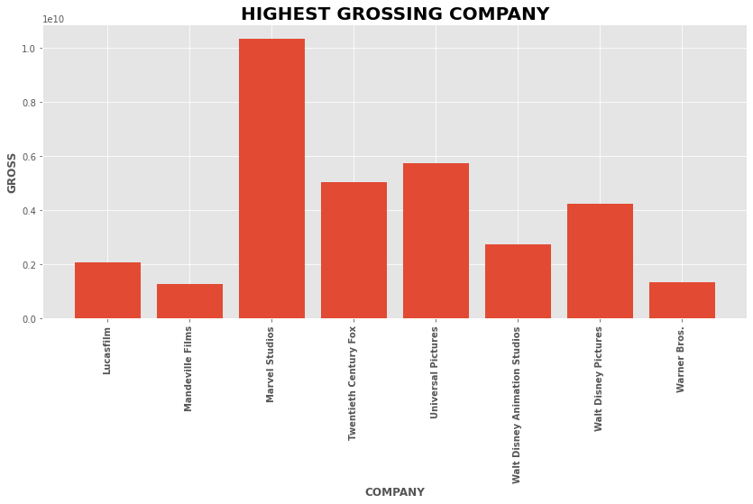

```python
companies = [comp for comp, df in check.groupby('company')]

plt.bar(companies, companySort['gross'])
plt.title('HIGHEST GROSSING COMPANY', fontweight=
        'bold', fontsize=20)
plt.xlabel('COMPANY',fontweight='bold')
plt.xticks(companies, fontweight='bold')
plt.ylabel('GROSS',fontweight='bold')
plt.xticks(companies, rotation='vertical', size=10, fontweight='bold')
plt.show()
```

Highest Grossing Director

```python
directorSort = check.groupby('director').sum()
directorSort
```

| director | votes | budget | gross |
| --- | --- | --- | --- |
| Anthony Russo | 1800000.0 | 677000000.0 | 4.845861e+09 |
| Bill Condon | 283000.0 | 160000000.0 | 1.264435e+09 |
| Brad Bird | 263000.0 | 200000000.0 | 1.244640e+09 |
| Chris Buck | 733000.0 | 300000000.0 | 2.731535e+09 |
| Colin Trevorrow | 593000.0 | 150000000.0 | 1.670516e+09 |
| David Yates | 790000.0 | 125000000.0 | 1.342322e+09 |
| F. Gary Gray | 214000.0 | 250000000.0 | 1.236005e+09 |
| J.A. Bayona | 277000.0 | 170000000.0 | 1.310466e+09 |
| J.J. Abrams | 876000.0 | 245000000.0 | 2.069522e+09 |
| James Cameron | 2200000.0 | 437000000.0 | 5.048893e+09 |
| James Wan | 370000.0 | 190000000.0 | 1.515341e+09 |
| Jon Favreau | 222000.0 | 260000000.0 | 1.670728e+09 |
| Joss Whedon | 2077000.0 | 470000000.0 | 2.921625e+09 |
| Rian Johnson | 581000.0 | 317000000.0 | 1.332699e+09 |
| Ryan Coogler | 661000.0 | 200000000.0 | 1.347598e+09 |
| Shane Black | 779000.0 | 200000000.0 | 1.214811e+09 |

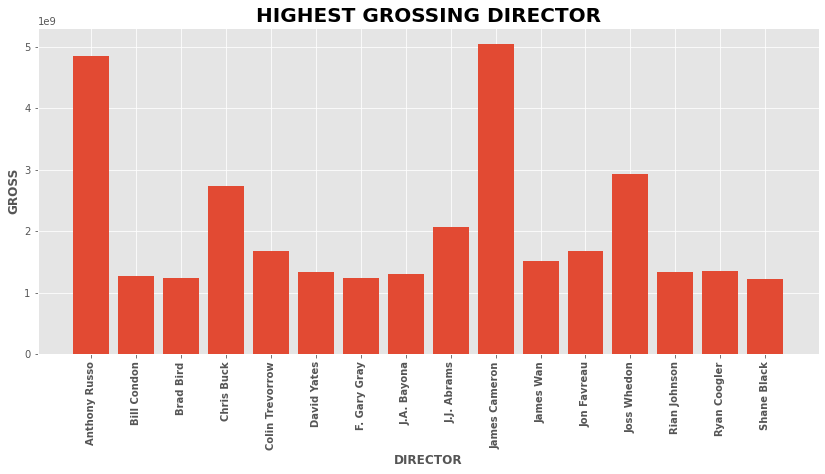

```python
directors = [dir for dir, df in check.groupby('director')]

plt.bar(directors, directorSort['gross'])
plt.title('HIGHEST GROSSING DIRECTOR', fontweight=
        'bold', fontsize=20)
plt.xlabel('DIRECTOR',fontweight='bold')
plt.xticks(directors, fontweight='bold')
plt.ylabel('GROSS',fontweight='bold')
plt.xticks(directors, rotation='vertical', size=10, fontweight='bold')
plt.show()
```

Highest Grossing Writer

```python
writerSort = data.groupby('writer').sum().sort_values(by=['gross'],ascending=False).head(20)
writerSort
```

| writer | year | score | votes | budget | gross | runtime |
| --- | --- | --- | --- | --- | --- | --- |
| Christopher Markus | 14101 | 51.9 | 4377000.0 | 1.418000e+09 | 7.587182e+09 | 979.0 |
| James Cameron | 15970 | 62.4 | 5155000.0 | 8.459000e+08 | 6.282146e+09 | 1144.0 |
| John Lasseter | 16051 | 58.2 | 3311000.0 | 1.010000e+09 | 4.656539e+09 | 785.0 |
| Chris Morgan | 14086 | 46.7 | 1968000.0 | 1.020000e+09 | 4.360332e+09 | 873.0 |
| Steve Kloves | 14001 | 50.9 | 2374200.0 | 5.445000e+08 | 4.184681e+09 | 934.0 |
| J.K. Rowling | 10041 | 36.7 | 2483000.0 | 7.350000e+08 | 4.152832e+09 | 721.0 |
| Ehren Kruger | 20069 | 62.0 | 1919000.0 | 1.077000e+09 | 4.103318e+09 | 1248.0 |
| Cinco Paul | 14076 | 45.5 | 1391000.0 | 4.610000e+08 | 3.911674e+09 | 634.0 |
| Ted Elliott | 8027 | 29.0 | 2768000.0 | 9.150000e+08 | 3.727154e+09 | 599.0 |
| Fran Walsh | 16061 | 57.4 | 2699000.0 | 1.062000e+09 | 3.710457e+09 | 1133.0 |
| Lawrence Kasdan | 19891 | 72.5 | 3012700.0 | 3.825000e+08 | 3.519337e+09 | 1213.0 |
| Melissa Rosenberg | 10050 | 25.3 | 1403000.0 | 3.850000e+08 | 3.359901e+09 | 608.0 |
| Bruce Geller | 10040 | 35.7 | 1839000.0 | 6.780000e+08 | 3.173172e+09 | 643.0 |
| Michael Crichton | 23934 | 75.0 | 2197900.0 | 7.890000e+08 | 3.138481e+09 | 1371.0 |
| Jeff Nathanson | 8045 | 27.7 | 1520000.0 | 6.820000e+08 | 3.075820e+09 | 479.0 |
| Joss Whedon | 10035 | 35.8 | 2792000.0 | 5.460000e+08 | 3.048630e+09 | 584.0 |
| Linda Woolverton | 10050 | 34.2 | 1358000.0 | 7.600000e+08 | 3.000399e+09 | 521.0 |
| J.R.R. Tolkien | 6006 | 26.4 | 4900000.0 | 2.810000e+08 | 2.991216e+09 | 558.0 |
| Jonathan Nolan | 8040 | 34.5 | 6800000.0 | 6.400000e+08 | 2.898522e+09 | 615.0 |
| Jennifer Lee | 6050 | 18.4 | 775000.0 | 4.000000e+08 | 2.864211e+09 | 314.0 |

Highest Grossing Movies

```python
moviesSort = check.groupby('name').sum().sort_values(by=['gross'],ascending=False).head(10)
moviesSort
```

| name | votes | budget | gross |
| --- | --- | --- | --- |
| Avatar | 1100000.0 | 237000000.0 | 2.847246e+09 |
| Avengers: Endgame | 903000.0 | 356000000.0 | 2.797501e+09 |
| Titanic | 1100000.0 | 200000000.0 | 2.201647e+09 |
| Star Wars: Episode VII - The Force Awakens | 876000.0 | 245000000.0 | 2.069522e+09 |
| Avengers: Infinity War | 897000.0 | 321000000.0 | 2.048360e+09 |
| The Lion King | 222000.0 | 260000000.0 | 1.670728e+09 |
| Jurassic World | 593000.0 | 150000000.0 | 1.670516e+09 |
| The Avengers | 1300000.0 | 220000000.0 | 1.518816e+09 |
| Furious 7 | 370000.0 | 190000000.0 | 1.515341e+09 |
| Frozen II | 148000.0 | 150000000.0 | 1.450027e+09 |

[figure not shown]

```python
movies = [mov for mov, df in check.groupby('name')]

plt.bar(movies, check['gross'])
plt.title('HIGHEST GROSSING MOVIES', fontweight=
        'bold', fontsize=20)
plt.xlabel('MOVIES',fontweight='bold')
plt.ylabel('GROSS',fontweight='bold')
plt.xticks(movies, rotation='vertical', size=10, fontweight='bold')
plt.show()
```

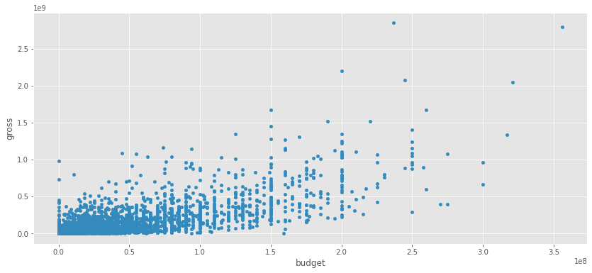

```python
data.plot.scatter(x='budget', y='gross', figsize=(14,6))
plt.show()
```

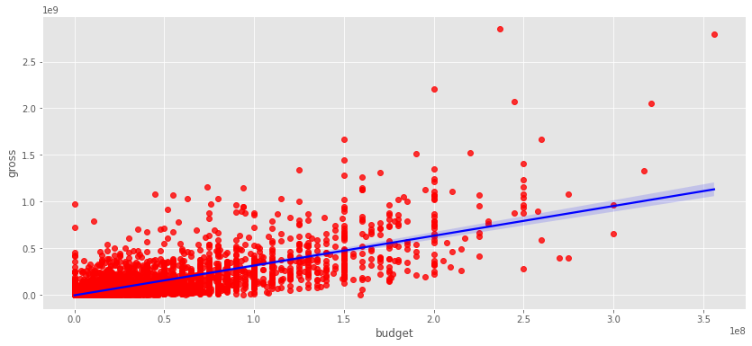

```python
sns.regplot(x='budget', y='gross', data=data, scatter_kws={'color':'red'}, line_kws={'color':'blue'})
```

Look for Correlations

```python
data.corr()
```

|  | year | score | votes | budget | gross | runtime |
| --- | --- | --- | --- | --- | --- | --- |
| year | 1.000000 | 0.097995 | 0.222427 | 0.309212 | 0.261900 | 0.120811 |
| score | 0.097995 | 1.000000 | 0.409182 | 0.055665 | 0.186392 | 0.399451 |
| votes | 0.222427 | 0.409182 | 1.000000 | 0.486931 | 0.632870 | 0.309122 |
| budget | 0.309212 | 0.055665 | 0.486931 | 1.000000 | 0.750157 | 0.269510 |
| gross | 0.261900 | 0.186392 | 0.632870 | 0.750157 | 1.000000 | 0.245235 |
| runtime | 0.120811 | 0.399451 | 0.309122 | 0.269510 | 0.245235 | 1.000000 |

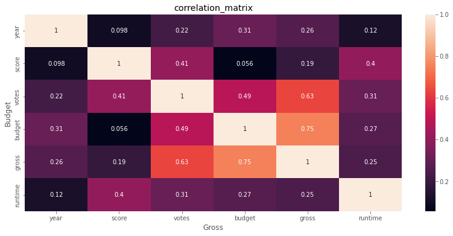

```python
correlation_matrix=data.corr()
sns.heatmap(correlation_matrix, annot= True)
plt.title('correlation_matrix')
plt.xlabel('Gross')
plt.ylabel('Budget')
plt.show()
```

```python
data.head()
```

|  | name | rating | genre | year | released | score | votes | director | writer | star | country | budget | gross | company | runtime |
| --- | --- | --- | --- | --- | --- | --- | --- | --- | --- | --- | --- | --- | --- | --- | --- |
| 0 | The Shining | R | Drama | 1980 | June 13, 1980 (United States) | 8.4 | 927000.0 | Stanley Kubrick | Stephen King | Jack Nicholson | United Kingdom | 19000000.0 | 46998772.0 | Warner Bros. | 146.0 |
| 1 | The Blue Lagoon | R | Adventure | 1980 | July 2, 1980 (United States) | 5.8 | 65000.0 | Randal Kleiser | Henry De Vere Stacpoole | Brooke Shields | United States | 4500000.0 | 58853106.0 | Columbia Pictures | 104.0 |
| 2 | Star Wars: Episode V - The Empire Strikes Back | PG | Action | 1980 | June 20, 1980 (United States) | 8.7 | 1200000.0 | Irvin Kershner | Leigh Brackett | Mark Hamill | United States | 18000000.0 | 538375067.0 | Lucasfilm | 124.0 |
| 3 | Airplane! | PG | Comedy | 1980 | July 2, 1980 (United States) | 7.7 | 221000.0 | Jim Abrahams | Jim Abrahams | Robert Hays | United States | 3500000.0 | 83453539.0 | Paramount Pictures | 88.0 |
| 4 | Caddyshack | R | Comedy | 1980 | July 25, 1980 (United States) | 7.3 | 108000.0 | Harold Ramis | Brian Doyle-Murray | Chevy Chase | United States | 6000000.0 | 39846344.0 | Orion Pictures | 98.0 |

```python
data_numerized = data.copy()
```

```python
data_numerized.head()
```

|  | name | rating | genre | year | released | score | votes | director | writer | star | country | budget | gross | company | runtime |
| --- | --- | --- | --- | --- | --- | --- | --- | --- | --- | --- | --- | --- | --- | --- | --- |
| 0 | The Shining | R | Drama | 1980 | June 13, 1980 (United States) | 8.4 | 927000.0 | Stanley Kubrick | Stephen King | Jack Nicholson | United Kingdom | 19000000.0 | 46998772.0 | Warner Bros. | 146.0 |
| 1 | The Blue Lagoon | R | Adventure | 1980 | July 2, 1980 (United States) | 5.8 | 65000.0 | Randal Kleiser | Henry De Vere Stacpoole | Brooke Shields | United States | 4500000.0 | 58853106.0 | Columbia Pictures | 104.0 |
| 2 | Star Wars: Episode V - The Empire Strikes Back | PG | Action | 1980 | June 20, 1980 (United States) | 8.7 | 1200000.0 | Irvin Kershner | Leigh Brackett | Mark Hamill | United States | 18000000.0 | 538375067.0 | Lucasfilm | 124.0 |
| 3 | Airplane! | PG | Comedy | 1980 | July 2, 1980 (United States) | 7.7 | 221000.0 | Jim Abrahams | Jim Abrahams | Robert Hays | United States | 3500000.0 | 83453539.0 | Paramount Pictures | 88.0 |
| 4 | Caddyshack | R | Comedy | 1980 | July 25, 1980 (United States) | 7.3 | 108000.0 | Harold Ramis | Brian Doyle-Murray | Chevy Chase | United States | 6000000.0 | 39846344.0 | Orion Pictures | 98.0 |

```python
for col_name in data_numerized.columns:
    if(data_numerized[col_name].dtype == 'object'):
        data_numerized[col_name] = data_numerized[col_name].astype('category')
        data_numerized[col_name] = data_numerized[col_name].cat.codes
data_numerized
```

```python
data
```

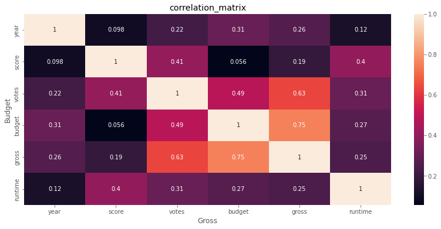

```python
correlation_matrix=data_numerized.corr()
sns.heatmap(correlation_matrix, annot= True)
plt.title('correlation_matrix')
plt.xlabel('Gross')
plt.ylabel('Budget')
plt.show()
```

```python
data_numerized.corr()
```

|  | year | score | votes | budget | gross | runtime |
| --- | --- | --- | --- | --- | --- | --- |
| year | 1.000000 | 0.097995 | 0.222427 | 0.309212 | 0.261900 | 0.120811 |
| score | 0.097995 | 1.000000 | 0.409182 | 0.055665 | 0.186392 | 0.399451 |
| votes | 0.222427 | 0.409182 | 1.000000 | 0.486931 | 0.632870 | 0.309122 |
| budget | 0.309212 | 0.055665 | 0.486931 | 1.000000 | 0.750157 | 0.269510 |
| gross | 0.261900 | 0.186392 | 0.632870 | 0.750157 | 1.000000 | 0.245235 |
| runtime | 0.120811 | 0.399451 | 0.309122 | 0.269510 | 0.245235 | 1.000000 |

```python
correlation_mat = data_numerized.corr()
corr_pairs = correlation_mat.unstack()
corr_pairs
```

```
year     year       1.000000
         score      0.097995
         votes      0.222427
         budget     0.309212
         gross      0.261900
         runtime    0.120811
score    year       0.097995
         score      1.000000
         votes      0.409182
         budget     0.055665
         gross      0.186392
         runtime    0.399451
votes    year       0.222427
         score      0.409182
         votes      1.000000
         budget     0.486931
         gross      0.632870
         runtime    0.309122
budget   year       0.309212
         score      0.055665
         votes      0.486931
         budget     1.000000
         gross      0.750157
         runtime    0.269510
gross    year       0.261900
         score      0.186392
         votes      0.632870
         budget     0.750157
         gross      1.000000
         runtime    0.245235
runtime  year       0.120811
         score      0.399451
         votes      0.309122
         budget     0.269510
         gross      0.245235
         runtime    1.000000
dtype: float64
```

```python
sorted_pairs = corr_pairs.sort_values()

sorted_pairs
```

```
score    budget     0.055665
budget   score      0.055665
year     score      0.097995
score    year       0.097995
year     runtime    0.120811
runtime  year       0.120811
gross    score      0.186392
score    gross      0.186392
year     votes      0.222427
votes    year       0.222427
gross    runtime    0.245235
runtime  gross      0.245235
year     gross      0.261900
gross    year       0.261900
runtime  budget     0.269510
budget   runtime    0.269510
votes    runtime    0.309122
runtime  votes      0.309122
budget   year       0.309212
year     budget     0.309212
runtime  score      0.399451
score    runtime    0.399451
votes    score      0.409182
score    votes      0.409182
votes    budget     0.486931
budget   votes      0.486931
gross    votes      0.632870
votes    gross      0.632870
budget   gross      0.750157
gross    budget     0.750157
year     year       1.000000
budget   budget     1.000000
votes    votes      1.000000
score    score      1.000000
gross    gross      1.000000
runtime  runtime    1.000000
dtype: float64
```

```python
high_corr = sorted_pairs[(sorted_pairs) > 0.5]

high_corr
```

```
gross    votes      0.632870
votes    gross      0.632870
budget   gross      0.750157
gross    budget     0.750157
year     year       1.000000
budget   budget     1.000000
votes    votes      1.000000
score    score      1.000000
gross    gross      1.000000
runtime  runtime    1.000000
dtype: float64
```

budget and votes have the highest correlation to gross earnings